# CAR Models

using Zimbabwe DHS data

KM Wambui

# Shape files in R

## Reading and exporting? the shape file

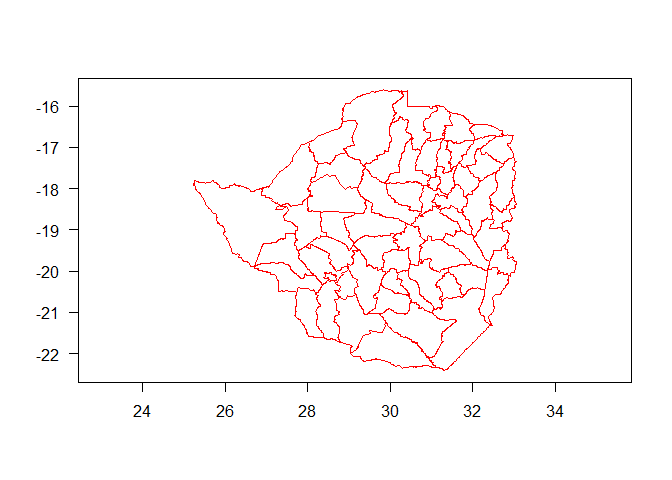

```r
zim_shp <- maptools::readShapePoly("zim_shape/ZWE_adm2.shp", IDvar = "ID_2")
plot(zim_shp, border = "red", axes = TRUE, las = 1)
```

## What R is reccommending

```r
zim_OGR <- rgdal::readOGR("zim_shape/ZWE_adm2.shp")
```

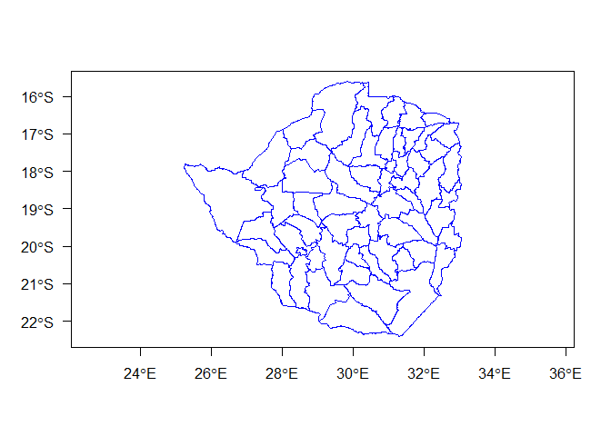

```r
plot(zim_OGR, border = "blue", axes = TRUE, las = 1)
```

We need to check our shape file to see if the spatial geometry is valid and the `gIsValid` function looks at each polygon, and makes sure it doesn’t break any topological rules. Ideally, all of the geometry is valid and the total number of polygons that fail the validity tests is 0.

```r
zim_valid <- data.table(valid = gIsValid(zim_OGR, byid = TRUE))
sum(zim_valid$valid == F)
```

```
[1] 0
```

# Zimbabwe HAZ (Stunting) CAR Model

## Load the data

The data is extracted from the Zimbabwean DHS. Our outcome variable is Stunting predicted by (Variable selection done earlier);

1. Employed - Employment status of the parent
2. b19 - Age of the child
3. Education - Education level of the parent
4. b4 - Sex of the child
5. v025 - Place of residence Urban or Rural
6. BMI - BMI calculated earlier

```r
# zim_child_data <- haven::read_dta('data/Data2.dta')
zim_child_data <- readstata13::read.dta13("data/Data2.dta")
# dplyr::glimpse(zim_child_data , width = 5)
```

## Explolatory Data Analysis

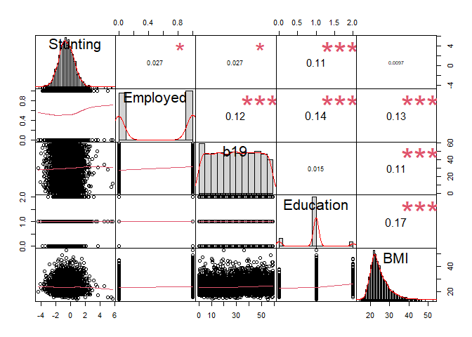

```r
## EDA
eda_data <- zim_child_data %>%
    select(Stunting, Employed, b19, Education, BMI)
PerformanceAnalytics::chart.Correlation(eda_data, histogram = TRUE, pch = 19)
```

## Select the variables of interest

What approaches can you use to select the variables of interest. - Stepwise regression [1^](http://web.nchu.edu.tw/~numerical/course1012/ra/Applied_Regression_Analysis_A_Research_Tool.pdf) - Regularization methods [2^](https://web.stanford.edu/~hastie/Papers/B67.2%20%282005%29%20301-320%20Zou%20&%20Hastie.pdf)

Here we have already selected the variables to use and we use complete case data.

```r
zim_child_model <- zim_child_data %>%
    select(id_2, name_1, name_2, Stunting, Employed, b19, Education, b4, v025, BMI)
zim_child_model <- zim_child_model[complete.cases(zim_child_model), ]

glimpse(zim_child_model)
```

```
Rows: 5,962
Columns: 10
$ id_2      <int> 1, 2, 3, 4, 5, 6, 7, 8, 9, 10, 11, 12, 13, 14, 15, 16, 17, 1~
$ name_1    <chr> "Bulawayo", "Harare", "Manicaland", "Manicaland", "Manicalan~
$ name_2    <chr> "Bulawayo", "Harare", "Buhera", "Chimanimani", "Chipinge", "~
$ Stunting  <dbl> -1.93, -0.86, -1.34, 0.80, 1.86, -0.32, 1.01, -1.06, -0.79, ~
$ Employed  <int> 1, 1, 1, 1, 1, 0, 1, 1, 1, 0, 1, 1, 0, 0, 0, 1, 0, 0, 0, 0, ~
$ b19       <int> 13, 44, 18, 27, 1, 28, 5, 16, 8, 32, 59, 36, 23, 48, 50, 29,~
$ Education <int> 1, 1, 1, 1, 1, 1, 1, 1, 1, 0, 0, 1, 1, 1, 1, 1, 1, 1, 1, 1, ~
$ b4        <fct> male, male, male, male, male, male, female, female, female, ~
$ v025      <fct> rural, rural, urban, rural, urban, rural, urban, rural, rura~
$ BMI       <dbl> 21.15, 37.29, 28.26, 21.70, 19.64, 19.56, 30.28, 28.82, 23.7~
```

Check whether the ID_2 on the shape file corresponds to what you have in your data

```r
table(zim_shp@data$ID_2 %in% zim_child_model$id_2)
```

```
TRUE
  60
```

```r
table(zim_shp@data$NAME_2 %in% zim_child_model$name_2)
```

```
TRUE
  60
```

## Linear regression model

```r
## Define the formula of the model
form_fit <- Stunting ~ Employed + b19 + as.factor(Education) + b4 + v025 + BMI

## fit the model
lin_mod <- glm(form_fit, data = zim_child_data, family = gaussian(link = "identity"))
```

Extract the summary statistics from the model. What do the estimates mean?

```r
summary(lin_mod)$coefficient
```

```
                          Estimate   Std. Error    t value     Pr(>|t|)
(Intercept)           -0.708127745 0.0906876251 -7.8084275 6.795954e-15
Employed               0.013977182 0.0275116631  0.5080457 6.114401e-01
b19                    0.001503499 0.0007767325  1.9356713 5.295526e-02
as.factor(Education)1  0.258544943 0.0406933905  6.3534874 2.260783e-10
as.factor(Education)2  0.487947342 0.0673593288  7.2439460 4.910341e-13
b4female               0.001661043 0.0266641938  0.0622949 9.503301e-01
v025rural             -0.063267906 0.0299378549 -2.1133079 3.461591e-02
BMI                   -0.004092509 0.0030319814 -1.3497803 1.771378e-01
```

```r
AIC(lin_mod)  # AIC => 17272
```

```
[1] 17272.36
```

```r
BIC(lin_mod)  # BIC => 17333
```

```
[1] 17332.6
```

## Check for the assumptions

We focus on the Residuals vs Fitted values and the Normal Q-Q. This will inform our decision on whether the outcome has met the assumptions to be used in further spatial models

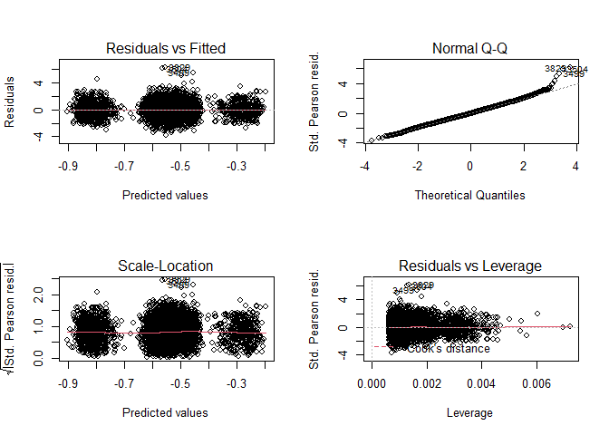

```r
par(mfrow = c(2, 2))  # display a unique layout for all graphs
plot(lin_mod)
```

```r
par(mfrow = c(1, 1))
```

# CAR model in INLA

## Normal linear model in INLA

```r
form_fit <-  Stunting ~1+ Employed +b19  +
  as.factor(Education) + b4+ v025+ BMI

model_linear <- inla(form_fit,
                     family="gaussian",
                     data=zim_child_model,
                    control.compute=list(dic=TRUE, waic=TRUE))
```

## Extracting the model summaries

Here we compare our glm model with the linear model from INLA, are they similar?

```r
summary(model_linear)
```

```
Call:
   c("inla(formula = form_fit, family = \"gaussian\", data =
   zim_child_model, ", " control.compute = list(dic = TRUE, waic =
   TRUE))")
Time used:
    Pre = 0.854, Running = 7.89, Post = 0.817, Total = 9.56
Fixed effects:
                        mean    sd 0.025quant 0.5quant 0.975quant   mode kld
(Intercept)           -0.708 0.091     -0.886   -0.708     -0.530 -0.708   0
Employed               0.014 0.028     -0.040    0.014      0.068  0.014   0
b19                    0.002 0.001      0.000    0.002      0.003  0.002   0
as.factor(Education)1  0.259 0.041      0.179    0.259      0.338  0.259   0
as.factor(Education)2  0.488 0.067      0.356    0.488      0.620  0.488   0
b4female               0.002 0.027     -0.051    0.002      0.054  0.002   0
v025rural             -0.063 0.030     -0.122   -0.063     -0.005 -0.063   0
BMI                   -0.004 0.003     -0.010   -0.004      0.002 -0.004   0

Model hyperparameters:
                                         mean    sd 0.025quant 0.5quant
Precision for the Gaussian observations 0.944 0.017      0.911    0.944
                                        0.975quant  mode
Precision for the Gaussian observations      0.978 0.944

Expected number of effective parameters(stdev): 8.04(0.001)
Number of equivalent replicates : 742.05

Deviance Information Criterion (DIC) ...............: 17272.44
Deviance Information Criterion (DIC, saturated) ....: 5973.37
Effective number of parameters .....................: 9.07

Watanabe-Akaike information criterion (WAIC) ...: 17272.83
Effective number of parameters .................: 9.45

Marginal log-Likelihood:  -8697.69
Posterior marginals for the linear predictor and
 the fitted values are computed
```

```r
summary(lin_mod)
```

```
Call:
glm(formula = form_fit, family = gaussian(link = "identity"),
    data = zim_child_data)

Deviance Residuals:
    Min       1Q   Median       3Q      Max
-3.7788  -0.6882  -0.0303   0.6685   6.2951

Coefficients:
                        Estimate Std. Error t value Pr(>|t|)
(Intercept)           -0.7081277  0.0906876  -7.808 6.80e-15 ***
Employed               0.0139772  0.0275117   0.508   0.6114
b19                    0.0015035  0.0007767   1.936   0.0530 .
as.factor(Education)1  0.2585449  0.0406934   6.353 2.26e-10 ***
as.factor(Education)2  0.4879473  0.0673593   7.244 4.91e-13 ***
b4female               0.0016610  0.0266642   0.062   0.9503
v025rural             -0.0632679  0.0299379  -2.113   0.0346 *
BMI                   -0.0040925  0.0030320  -1.350   0.1771
---
Signif. codes:  0 '***' 0.001 '**' 0.01 '*' 0.05 '.' 0.1 ' ' 1

(Dispersion parameter for gaussian family taken to be 1.059208)

    Null deviance: 6399.5  on 5961  degrees of freedom
Residual deviance: 6306.5  on 5954  degrees of freedom
AIC: 17272

Number of Fisher Scoring iterations: 2
```

Extracting the summary of the fixed effects

```r
round(model_linear$summary.fixed[, 1:5], 3)
```

```
                        mean    sd 0.025quant 0.5quant 0.975quant
(Intercept)           -0.708 0.091     -0.886   -0.708     -0.530
Employed               0.014 0.028     -0.040    0.014      0.068
b19                    0.002 0.001      0.000    0.002      0.003
as.factor(Education)1  0.259 0.041      0.179    0.259      0.338
as.factor(Education)2  0.488 0.067      0.356    0.488      0.620
b4female               0.002 0.027     -0.051    0.002      0.054
v025rural             -0.063 0.030     -0.122   -0.063     -0.005
BMI                   -0.004 0.003     -0.010   -0.004      0.002
```

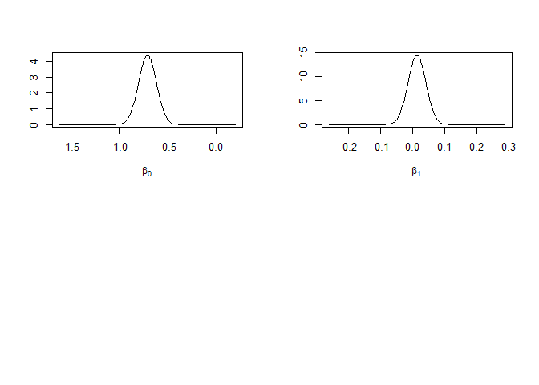

```r
par(mfrow = c(2, 2))  # display a unique layout for all graphs
## Posterior density plot for the intercepts
plot(model_linear$marginals.fixed[[1]], type = "l", main = "", ylab = "", xlab = expression(beta[0]))
plot(model_linear$marginals.fixed[[2]], type = "l", main = "", ylab = "", xlab = expression(beta[1]))
par(mfrow = c(1, 1))
```